# Psych パッケージ

奥村 太一（滋賀大学データサイエンス学部）

2021/06/25

## 概要

psych は、Dr. William Revelle (Northwestern University) による心理データ分析のための R パッケージである。 特に、項目得点を集計しての尺度得点化（逆転項目の処理など）や信頼性の評価、因子分析の実行などの分析メニューが充実している。 [CRAN のページ](https://cran.r-project.org/web/packages/psych/index.html)に様々な解説が掲載されている。

なお、ここでの説明は psych パッケージの Ver. 2.1.3 による。

## psych パッケージの読みこみ

psych パッケージを読み込んでおく。  
（インストールしていない場合は、`install.packages()` によってインストールしておく。）[^1]

```r
# install.packages("psych", dependencies = TRUE) # インストールしていない場合
library(psych)
packageVersion("psych") # バージョンの確認
```

```
## [1] '2.1.3'
```

## データの読み込み

ここでは、psych パッケージに用意されている bfi データを用いることにする。 これは、Big Five に関する質問紙への回答データ 2,800 人分。

25項目の Big Five 質問は「全く違う = 1」から「全くその通り = 6」で得点化されている。

- A1-A5: agreeableness（協調性）
- C1-C5: conscientiousness（誠実性）
- E1-E5: extraversion（外向性）
- N1-N5: neuroticism（神経症傾向）
- O1-O5: openness（開放性）
- gender: 性別（男 = 1, 女 = 2）
- education: 学歴（1 = 高校生まで 〜 5 = 高等教育修了）
- age: 年齢

詳しくは[こちら](https://www.personality-project.org/r/html/bfi.html)。 （もしくは、`help(bfi)` で確認できる。）

```r
data(bfi) # データセット bfi の読み込み
```

無論、データがテキスト形式等で用意されている場合などは、`read.table` とか `read.csv` とかを使って読み込めば良い。

## データのチェック

データの最初と終わりの数行ずつを表示する `headTail` 関数が用意されている。  
`describe` 関数は、変数ごとに記述統計量を算出するもの。[^2]

```r
dim(bfi) # データのサイズを確認
```

```
## [1] 2800   28
```

```r
headTail(bfi) # データの最初と終わりの数行を確認
```

```
##        A1  A2  A3  A4  A5  C1  C2  C3  C4  C5  E1  E2  E3  E4  E5   N1  N2  N3
## 61617   2   4   3   4   4   2   3   3   4   4   3   3   3   4   4    3   4   2
## 61618   2   4   5   2   5   5   4   4   3   4   1   1   6   4   3    3   3   3
## 61620   5   4   5   4   4   4   5   4   2   5   2   4   4   4   5    4   5   4
## 61621   4   4   6   5   5   4   4   3   5   5   5   3   4   4   4    2   5   2
## ...   ... ... ... ... ... ... ... ... ... ... ... ... ... ... ...  ... ... ...
## 67552   2   4   4   3   5   2   3   4   4   3   2   2   4   4   3 <NA>   3   2
## 67556   2   3   5   2   5   5   5   5   1   1   2   2   6   3   6    3   4   3
## 67559   5   2   2   4   4   5   5   5   2   6   2   2   4   5   4    5   5   6
## 67560   2   3   1   4   2   5   5   3   3   3   3   3   1   2   2    1   2   2
##        N4  N5  O1  O2  O3  O4  O5 gender education age
## 61617   2   3   3   6   3   4   3      1      <NA>  16
## 61618   5   5   4   2   4   3   3      2      <NA>  18
## 61620   2   3   4   2   5   5   2      2      <NA>  17
## 61621   4   1   3   3   4   3   5      2      <NA>  17
## ...   ... ... ... ... ... ... ...    ...       ... ...
## 67552   3   3   6   3   5   4   2      1         4  27
## 67556   3   1   5   1   6   4   3      2         4  29
## 67559   4   1   5   2   5   5   1      1         4  31
## 67560   1   1   3   1   3   5   1      2         4  50
```

```r
describe(bfi)
```

```
##           vars    n  mean    sd median trimmed   mad min max range  skew
## A1           1 2784  2.41  1.41      2    2.23  1.48   1   6     5  0.83
## A2           2 2773  4.80  1.17      5    4.98  1.48   1   6     5 -1.12
## A3           3 2774  4.60  1.30      5    4.79  1.48   1   6     5 -1.00
## A4           4 2781  4.70  1.48      5    4.93  1.48   1   6     5 -1.03
## A5           5 2784  4.56  1.26      5    4.71  1.48   1   6     5 -0.85
## C1           6 2779  4.50  1.24      5    4.64  1.48   1   6     5 -0.85
## C2           7 2776  4.37  1.32      5    4.50  1.48   1   6     5 -0.74
## C3           8 2780  4.30  1.29      5    4.42  1.48   1   6     5 -0.69
## C4           9 2774  2.55  1.38      2    2.41  1.48   1   6     5  0.60
## C5          10 2784  3.30  1.63      3    3.25  1.48   1   6     5  0.07
## E1          11 2777  2.97  1.63      3    2.86  1.48   1   6     5  0.37
## E2          12 2784  3.14  1.61      3    3.06  1.48   1   6     5  0.22
## E3          13 2775  4.00  1.35      4    4.07  1.48   1   6     5 -0.47
## E4          14 2791  4.42  1.46      5    4.59  1.48   1   6     5 -0.82
## E5          15 2779  4.42  1.33      5    4.56  1.48   1   6     5 -0.78
## N1          16 2778  2.93  1.57      3    2.82  1.48   1   6     5  0.37
## N2          17 2779  3.51  1.53      4    3.51  1.48   1   6     5 -0.08
## N3          18 2789  3.22  1.60      3    3.16  1.48   1   6     5  0.15
## N4          19 2764  3.19  1.57      3    3.12  1.48   1   6     5  0.20
## N5          20 2771  2.97  1.62      3    2.85  1.48   1   6     5  0.37
## O1          21 2778  4.82  1.13      5    4.96  1.48   1   6     5 -0.90
## O2          22 2800  2.71  1.57      2    2.56  1.48   1   6     5  0.59
## O3          23 2772  4.44  1.22      5    4.56  1.48   1   6     5 -0.77
## O4          24 2786  4.89  1.22      5    5.10  1.48   1   6     5 -1.22
## O5          25 2780  2.49  1.33      2    2.34  1.48   1   6     5  0.74
## gender      26 2800  1.67  0.47      2    1.71  0.00   1   2     1 -0.73
## education   27 2577  3.19  1.11      3    3.22  1.48   1   5     4 -0.05
## age         28 2800 28.78 11.13     26   27.43 10.38   3  86    83  1.02
##           kurtosis   se
## A1           -0.31 0.03
## A2            1.05 0.02
## A3            0.44 0.02
## A4            0.04 0.03
## A5            0.16 0.02
## C1            0.30 0.02
## C2           -0.14 0.03
## C3           -0.13 0.02
## C4           -0.62 0.03
## C5           -1.22 0.03
## E1           -1.09 0.03
## E2           -1.15 0.03
## E3           -0.47 0.03
## E4           -0.30 0.03
## E5           -0.09 0.03
## N1           -1.01 0.03
## N2           -1.05 0.03
## N3           -1.18 0.03
## N4           -1.09 0.03
## N5           -1.06 0.03
## O1            0.43 0.02
## O2           -0.81 0.03
## O3            0.30 0.02
## O4            1.08 0.02
## O5           -0.24 0.03
## gender       -1.47 0.01
## education    -0.32 0.02
## age           0.56 0.21
```

この時点で平均が極端に低い（取りうる最小値に近い：**床効果** *floor effect*）とか高い（取りうる最大値に近い：**天井効果** *ceiling effect*）とか、SD がゼロに近いといったように回答者の個人差を検出するのに役にたっていないような変数は分析から外してしまう場合もある。 この場合は O1 や O4 の平均が高めではあるが、SD は他と同じくらい大きいので大丈夫だろう。

変数間の相関行列は `lowerCor` 関数で算出できる（下三角部分、小数点以下第2位まで）。 `corPlot` 関数を用いると、相関行列をヒートマップで表示できる。

```r
r <- lowerCor(bfi[, 1:25]) # A1-O5 まで25変数の相関行列（下三角部分）
```

```
##    A1    A2    A3    A4    A5    C1    C2    C3    C4    C5    E1
## A1  1.00
## A2 -0.34  1.00
## A3 -0.27  0.49  1.00
## A4 -0.15  0.34  0.36  1.00
## A5 -0.18  0.39  0.50  0.31  1.00
## C1  0.03  0.09  0.10  0.09  0.12  1.00
## C2  0.02  0.14  0.14  0.23  0.11  0.43  1.00
## C3 -0.02  0.19  0.13  0.13  0.13  0.31  0.36  1.00
## C4  0.13 -0.15 -0.12 -0.15 -0.13 -0.34 -0.38 -0.34  1.00
## C5  0.05 -0.12 -0.16 -0.24 -0.17 -0.25 -0.30 -0.34  0.48  1.00
## E1  0.11 -0.21 -0.21 -0.11 -0.25 -0.02  0.02  0.00  0.09  0.06  1.00
## E2  0.09 -0.23 -0.29 -0.19 -0.33 -0.09 -0.06 -0.08  0.20  0.26  0.47
## E3 -0.05  0.25  0.39  0.19  0.42  0.12  0.15  0.09 -0.08 -0.16 -0.33
## E4 -0.06  0.28  0.38  0.30  0.47  0.14  0.12  0.09 -0.11 -0.20 -0.42
## E5 -0.02  0.29  0.25  0.16  0.27  0.25  0.25  0.21 -0.24 -0.23 -0.30
## N1  0.17 -0.09 -0.08 -0.10 -0.20 -0.07 -0.02 -0.07  0.22  0.21  0.02
## N2  0.14 -0.05 -0.09 -0.14 -0.19 -0.04 -0.01 -0.06  0.16  0.25  0.01
## N3  0.10 -0.04 -0.04 -0.07 -0.14 -0.03  0.00 -0.07  0.21  0.24  0.05
## N4  0.05 -0.09 -0.13 -0.17 -0.20 -0.10 -0.05 -0.11  0.26  0.34  0.23
## N5  0.02  0.02 -0.04 -0.01 -0.08 -0.05  0.05 -0.01  0.20  0.17  0.05
## O1  0.01  0.13  0.15  0.06  0.16  0.17  0.16  0.09 -0.09 -0.08 -0.10
## O2  0.08  0.02  0.00  0.04  0.00 -0.11 -0.04 -0.03  0.21  0.14  0.04
## O3 -0.06  0.16  0.22  0.07  0.24  0.19  0.19  0.06 -0.08 -0.08 -0.22
## O4 -0.08  0.09  0.04 -0.04  0.02  0.11  0.06  0.02  0.05  0.14  0.08
## O5  0.11 -0.09 -0.05  0.02 -0.05 -0.12 -0.05 -0.01  0.20  0.06  0.10
##    E2    E3    E4    E5    N1    N2    N3    N4    N5    O1    O2
## E2  1.00
## E3 -0.38  1.00
## E4 -0.51  0.42  1.00
## E5 -0.37  0.38  0.32  1.00
## N1  0.17 -0.05 -0.14  0.04  1.00
## N2  0.19 -0.07 -0.14  0.04  0.71  1.00
## N3  0.20 -0.02 -0.10 -0.06  0.56  0.55  1.00
## N4  0.35 -0.15 -0.29 -0.21  0.40  0.39  0.52  1.00
## N5  0.25 -0.07 -0.09 -0.13  0.38  0.35  0.43  0.40  1.00
## O1 -0.16  0.33  0.14  0.30 -0.05 -0.05 -0.03 -0.05 -0.12  1.00
## O2  0.08 -0.07  0.06 -0.08  0.13  0.13  0.11  0.08  0.20 -0.21  1.00
## O3 -0.23  0.39  0.21  0.29 -0.05 -0.03 -0.03 -0.06 -0.08  0.40 -0.26
## O4  0.17  0.05 -0.10  0.00  0.08  0.13  0.18  0.21  0.11  0.18 -0.07
## O5  0.08 -0.11  0.05 -0.11  0.11  0.04  0.06  0.04  0.14 -0.24  0.32
##    O3    O4    O5
## O3  1.00
## O4  0.19  1.00
## O5 -0.31 -0.18  1.00
```

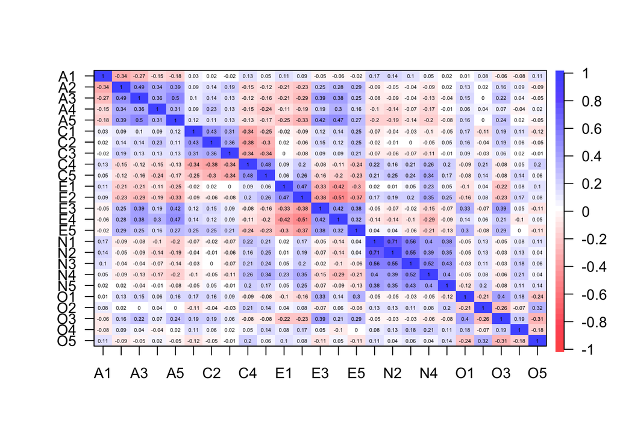

```r
corPlot(r) # 相関行列のヒートマップ
```

これを見ると明らかなように、Big Five 25項目には逆転項目が含まれている。 （ちなみに、逆転項目は A1, C4, C5, E1, E2, O2, O5 の7つである。）

## 尺度得点の算出

当初の仮説通り5因子にまとまるかどうかは因子分析を実行してみないとわからないが、ここではひとまずそれは成り立っているとして、各尺度（協調性、誠実性、外向性、神経症傾向、開放性）の得点を算出することにしよう。

### 逆転項目の扱い方

まずは、逆転項目の処理を行っておく。

逆転項目の得点を $x$ とすると、逆転処理後の得点 $x'$ は

$$x' = (\mathrm{[max~of~}x] + 1) - x$$

で計算できる。

処理の仕方としては、

1. あらかじめこれらの項目の得点を入れ替えたデータセットを作っておいてそれを以降の分析で用いる方法
2. それぞれの分析ごとに逆転項目であることを指定して処理させる方法

の2つが考えられる。

1. のやり方だと分析しているうちに逆転項目があったこと自体を忘れてしまって結果の解釈を誤る可能性がある（項目の内容と相関の符号が逆になるのでややこしい）一方、一度処理を済ませてしまえばあとは逆転処理を気にせず分析できる。
2. のやり方だと常に逆転処理のことを頭に入れておくことになるが、分析のたびごとに逆転項目を指定するのは煩雑であるし、そもそもそういったオプションが用意されていない分析メニューも多い。

いずれの方法も一長一短なのだが、項目分析（項目得点と尺度得点の相関関係を吟味するなど）の場合には項目の内容と相関の方向が一致していた方が解釈しやすいので②を取ることにしよう。 幸い、尺度得点の算出に当たっては、逆転処理を行うオプションが用意されている。

### ビッグファイブ得点の算出

尺度得点を算出する関数は `scoreItems` として用意されている。 ここに逆転項目を指定する引数 `keys =` で逆転項目を指定してやれば良い。

各下位尺度における逆転項目のリストを作成する。 変数名に `-`（マイナス） をつけることで、それが逆転項目として扱われる。 このリストは、どの項目によって尺度が構成されているかの指定も兼ねている。

bfi データのビッグファイブ項目では、逆転項目は A1, C4, C5, E1, E2, O2, O5 の7つである。

```r
keys.list <- list(agr = c("-A1", "A2", "A3", "A4", "A5"),  # agreeableness: A1が逆転
                  con = c("C1", "C2", "C3", "-C4", "-C5"), # concientiousness: C4とC5が逆転
                  ext = c("-E1", "-E2", "E3", "E4", "E5"), # extraversion: E1とE2が逆転
                  neu = c("N1", "N2", "N3", "N4", "N5"),   # neurotisism
                  opn = c("O1", "-O2", "O3", "O4", "-O5")) # openness: O2とO5が逆転
```

このリストを用いて、`scoreItem` によって尺度得点を算出する。 引数は次の通り。

- `keys =`: 尺度名と項目の対応リスト
- `items =`: 項目得点が含まれた元々のデータフレーム
- `min =`: 項目得点の最小値
- `max =`: 項目得点の最大値

デフォルトでは、項目得点の平均が尺度得点となる。 もし合計得点を算出したい場合は、引数 `totals = TRUE` と指定すれば良い。

```r
scores <- scoreItems(keys = keys.list, items = bfi, min = 1, max = 6) # 尺度得点を計算して scores に代入
names(scores) # アウトプットに含まれるオブジェクトを確認
```

```
##  [1] "scores"         "missing"        "alpha"          "av.r"
##  [5] "sn"             "n.items"        "item.cor"       "cor"
##  [9] "corrected"      "G6"             "item.corrected" "response.freq"
## [13] "raw"            "ase"            "med.r"          "keys"
## [17] "Call"
```

`scoreItems` によって作られるアウトプットには様々な値が含まれている。 それぞれ、`アウトプット$名前` でアクセスできる。

- `scores` : 尺度得点
- `alpha` : 各尺度のα係数（信頼性を評価するための指標の一つ）
- `n.items` : 各尺度の項目数
- `cor` : 尺度得点間の相関行列
- `item.corrected`: 項目得点と尺度得点の相関係数（修正済み）

```r
head(scores$scores) # 尺度得点の先頭行を表示
```

```
##       agr con ext neu opn
## 61617 4.0 2.8 3.8 2.8 3.0
## 61618 4.2 4.0 5.0 3.8 4.0
## 61620 3.8 4.0 4.2 3.6 4.8
## 61621 4.6 3.0 3.6 2.8 3.2
## 61622 4.0 4.4 4.8 3.2 3.6
## 61623 4.6 5.6 5.6 3.0 5.0
```

```r
scores$alpha # 各尺度のα係数
```

```
##             agr       con       ext       neu       opn
## alpha 0.7012375 0.7246871 0.7596948 0.8117752 0.5967716
```

```r
scores$n.items # 項目数
```

```
## agr con ext neu opn
##   5   5   5   5   5
```

```r
scores$cor # 尺度得点間の相関行列
```

```
##            agr        con        ext         neu         opn
## agr  1.0000000  0.2579797  0.4617888 -0.18464247  0.14718822
## con  0.2579797  1.0000000  0.2620508 -0.23364548  0.19414323
## ext  0.4617888  0.2620508  1.0000000 -0.22281890  0.21538683
## neu -0.1846425 -0.2336455 -0.2228189  1.00000000 -0.08573302
## opn  0.1471882  0.1941432  0.2153868 -0.08573302  1.00000000
```

```r
scores$item.corrected # 項目-全体相関（修正済み）
```

```
##            agr         con         ext          neu          opn
## A1 -0.38817168 -0.05636868 -0.10775523  0.137631728 -0.136226895
## A2  0.67247062  0.23271884  0.39875955 -0.070781580  0.172143382
## A3  0.70369351  0.22267892  0.47655389 -0.110398513  0.172534193
## A4  0.48552417  0.29420551  0.29907025 -0.139956578  0.006722974
## A5  0.62060465  0.22785027  0.54718895 -0.231569995  0.177287229
## C1  0.12655747  0.53397971  0.18911813 -0.083831792  0.279228211
## C2  0.21545980  0.60689411  0.16831158 -0.004594647  0.199184069
## C3  0.20943514  0.53763128  0.14441102 -0.094071562  0.078721306
## C4 -0.23643567 -0.66121393 -0.22731343  0.306329520 -0.230407441
## C5 -0.26345834 -0.59155711 -0.28852039  0.356056256 -0.099593062
## E1 -0.30299491 -0.06008897 -0.58940519  0.105842631 -0.155636114
## E2 -0.38997240 -0.24691036 -0.69748158  0.338083166 -0.152179742
## E3  0.44212852  0.20430021  0.60116451 -0.103929627  0.370677638
## E4  0.51358208  0.22882867  0.68128502 -0.219732036  0.039603639
## E5  0.33951112  0.39701692  0.54861315 -0.098924658  0.309249169
## N1 -0.22239316 -0.21001664 -0.10987526  0.759750659 -0.119132858
## N2 -0.21657671 -0.18949535 -0.12463818  0.744323220 -0.059637554
## N3 -0.13603592 -0.19802062 -0.14105892  0.736521723 -0.033261328
## N4 -0.22375038 -0.30512975 -0.39306074  0.621267752 -0.020662933
## N5 -0.04107039 -0.14005698 -0.19481464  0.544204240 -0.182376461
## O1  0.16531779  0.19541475  0.31308411 -0.087102738  0.521539519
## O2 -0.00848592 -0.18436092 -0.06898581  0.189486364 -0.445424924
## O3  0.25757570  0.19918527  0.41788948 -0.072883976  0.607480463
## O4  0.05718279 -0.01788274 -0.10437366  0.207044301  0.317075141
## O5 -0.09418589 -0.14405326 -0.11271896  0.114354198 -0.532654989
```

### 項目-全体相関

ここで、`item.corrected` に格納される項目得点と尺度得点との相関を**項目-全体相関**とか**I-T相関**（*item whole correlations*, *item-total correlations*）と呼ぶ。 これは、各項目がその構成概念を測定するツールとして適切に機能しているか確認するために参照される。 例えば、項目A1は

- I Am indifferent to the feelings of others.（他人の気持ちには無関心である）

という内容なのだが、これは agreeableness（協調性）の逆転項目である。 ということは、項目 A1 の得点は協調性尺度の得点（先ほど `agr` というラベルをつけた）と負の相関関係にないとまずはおかしい。 項目 A1 と協調性尺度の得点 agr の項目-全体相関は、

```r
scores$item.corrected["A1", "agr"] # 項目 A1 と協調性尺度得点の項目-全体相関
```

```
## [1] -0.3881717
```

より -0.3881717 であり、確かに負の相関関係となっている。 つまり、「他人の気持ちには無関心である」という質問項目が高い得点となっている（=肯定的な回答をしている）人ほど協調性得点が低いということであるから、この項目の中身としてつじつまがあっていると言えそうだ。

念のために、これが本当に項目 A1 の得点と協調性尺度得点の相関係数なのか、`cor` 関数を使って確かめておこう。

```r
cor(bfi$A1, scores$scores[, "agr"], use = "pairwise") # 項目 A1 と協調性尺度の相関
```

```
## [1] -0.5783427
```

普通に相関係数を算出すると、-0.5783427 とさっきよりも強い関係があることになっている。

なぜこうなるのかというと、上記のように普通に協調性尺度得点を用いるとその中にも項目 A1 の得点は含まれていることになる。 もし尺度を構成する項目数が少ないと、このやり方では他の項目とさして相関関係がなくとも尺度得点とは相関関係があることになる。

これに対して、`scoreItems` を用いて算出される項目-全体相関は、項目自分自身の得点を尺度得点に含まないように修正をかけたものになっている。 つまり、各項目が尺度得点とどれくらい相関しているかを過大に評価しないよう工夫しているということだ。

項目-全体相関が（正でも負でも）大きい項目は、それだけその項目得点の高低によって構成概念の個人差をよりしっかりと識別する能力があることを示しているから、これを項目の**識別力** *discrimination*と呼ぶこともある。 識別力があまりにも低い項目は同じ尺度に含まれる他の項目と異質であるということであるし、その構成概念を測定するのにそもそも妥当でない可能性があるので、尺度から省いた方がいいかもしれない。 このデータではいずれも大丈夫そうだ。

### 尺度得点のチェック

算出された5つの尺度得点について、記述統計量を計算しておこう。

```r
describe(scores$scores)
```

```
##     vars    n mean   sd median trimmed  mad min max range  skew kurtosis   se
## agr    1 2800 4.65 0.89    4.8    4.73 0.89 1.0   6   5.0 -0.77     0.44 0.02
## con    2 2800 4.27 0.95    4.4    4.31 0.89 1.0   6   5.0 -0.41    -0.16 0.02
## ext    3 2800 4.15 1.05    4.2    4.20 1.19 1.0   6   5.0 -0.48    -0.19 0.02
## neu    4 2800 3.16 1.19    3.0    3.13 1.19 1.0   6   5.0  0.22    -0.65 0.02
## opn    5 2800 4.59 0.80    4.6    4.62 0.89 1.2   6   4.8 -0.34    -0.28 0.02
```

また、得点間の相関関係もチェックしてみよう。 `pairs.panels` 関数を用いると散布図行列を描くことができる。

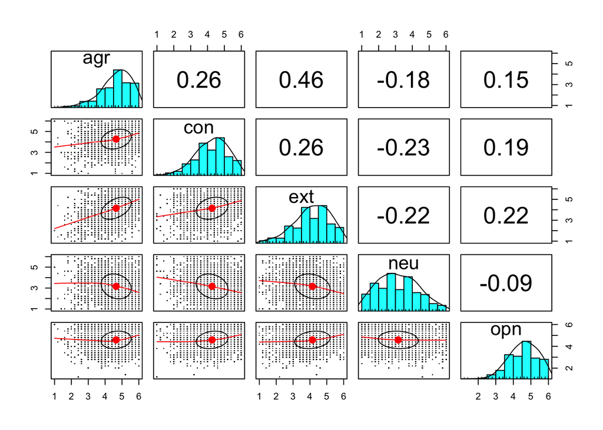

```r
pairs.panels(scores$scores, pch = ".")
```

先ほどの記述統計量と合わせてみても、協調性 agreeablness, 誠実性 conscientiousness, 外向性 extraversion, 開放性 openness はいずれも負に歪んだ分布となっており、平均もやや最大値方向に寄っている。 これらの尺度に含まれる質問項目については、いずれも「その通り」と答えやすいものだったのだろう。 これらの構成概念については、もっと高い人でないと肯定的な回答をしにくいような（能力テストでいえば困難度の高い）項目をもっと含めるべきだったのかもしれない。

## 因子分析

### 因子数の決定

因子分析を実行するためには、まず共通因子の数（因子数）を決定する必要がある。 今回のデータはパーソナリティが5次元で説明できるという Big Five 理論に基づいているので、最初から因子数を5として分析するのでもよい。

こうした理論的枠組みがない場合、あるいはもともと特定の因子数を想定して項目を作成したのであっても、本当にデータがそれを支持しているのか確認しておきたい場合は、データから妥当な因子数の手がかりを得ることになる。 いずれも最終的には解釈のしやすさから人間が判断するものであって、絶対的な正解や基準を与えるものではない。

#### 平行分析

まず、相関係数行列の固有値に注目した方法として**平行分析** *parallel analysis* と呼ばれるものがある。 相関行列をスペクトル分解（固有値と固有ベクトルの積和に分解）すると、変数の線形結合で表現される主成分得点について、その分散が固有値として得られる。 主成分分析では、抽出する次元数までの固有値を合計したものの割合を累積寄与率として主成分数決定の参考にする。 つまり、いくつの大きいまとまりを相関行列から作ることができるのか、が大きな固有値の数に表れるということである。

因子分析でも同様の手続きを取るのだが、データから算出された固有値をそのまま用いると、因子数が多すぎたり少なすぎたりするという指摘がシミュレーションにより報告されるようになった。 これに対応するものとして提案されたのが平行分析である。

平行分析では、データと同じサイズのデータをランダムに発生させて相関行列の固有値を算出するという作業を複数回繰り返し、それらの固有値の平均をプロットするということを行う。 その上で、観測データから計算された固有値がランダムなデータから得られた固有値を上回るところまでの数を因子数とするというものである。

psych パッケージでは、`fa.parallel` 関数によって平行分析を実行できる。

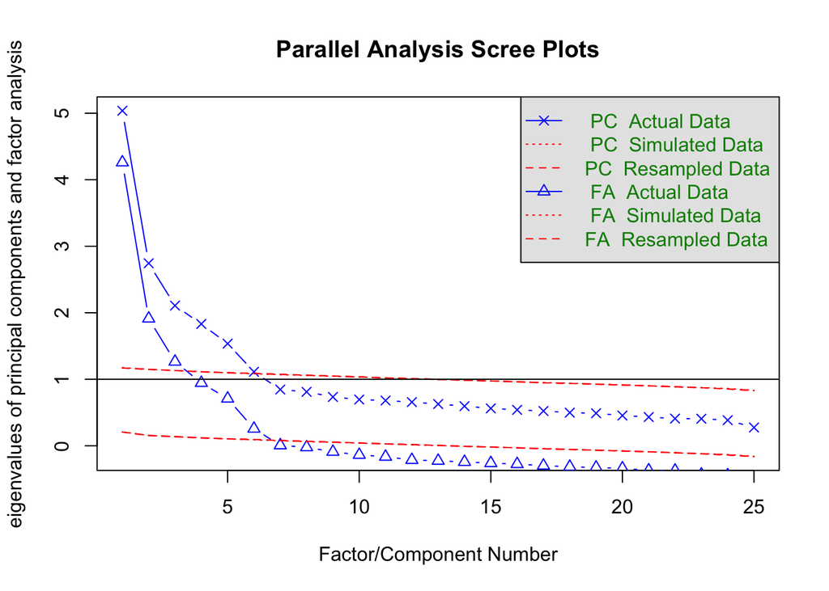

```
## Parallel analysis suggests that the number of factors =  6  and the number of components =  6
```

```r
fa.parallel(bfi[, 1:25])  # 変数1〜25を用いて平行分析を実施
```

出力されるプロットでは、観測データとランダムデータそれぞれから算出された固有値が大きい順に並んでいる。[^3] これをスクリープロットと呼ぶ。 プロットのうち `PC` とあるのは主成分分析に対応したもので、`FA` とあるのが因子分析（相関行列の対角成分を共通性に置き換える）に対応したものである。[^4]

このデータでは、共通因子の数を 6 とすることが提案されている。

#### 最小平均偏相関

これは、最小平均偏相関 *Minimum Average Partial correlation: MAP* という指標を因子数を変えながら算出し、MAP が最小になったところを因子数とするというものである。

今、因子数を $m$ として、この場合の因子パターンを $\bf A_m$ で表す。 このとき、

$$\bf R^*_m = D^{-1/2} (R- A_m A_m') D^{-1/2}$$
を偏相関行列という。 ただし、$\bf R$ は $p \times p$ の相関行列、$\bf D$ は $\bf R- A_m A_m'$ （これを偏共分散行列という）の対角成分を格納したものである。

直感的には、相関行列から $m$ 個の共通因子で説明できる部分を取り除いて標準化しなおしたものが $\bf R^*_m$ ということになる。

MAP は、偏相関行列の非対角成分の2乗和を平均したもの

$$\mathit{MAP}_m = \frac{\sum \sum_{i \neq j} r_{ij}^{*2}}{p(p-1)}$$
と定義する。

因子数 $m$ を大きくしていくと、MAP は一旦減少し、再度増加するという変化を見せる。 というのも、共通因子が残っている場合は非対角成分から共通項が括り出されるので MAP は減少する（対角行列に近づいていく）が、共通因子がなくなってしまえばあとは個々の観測変数に対応する部分が対角成分から抽出されるだけだからである。 そこで、MAP が最小になる因子数を採用すればよいという考えにつながる。

psych パッケージでは、`VSS` という関数で MAP を計算できる。

```r
out.vss <- VSS(bfi[, 1:25], plot = FALSE) # MAP の算出
out.vss
```

```
##
## Very Simple Structure
## Call: vss(x = x, n = n, rotate = rotate, diagonal = diagonal, fm = fm,
##     n.obs = n.obs, plot = plot, title = title, use = use, cor = cor)
## VSS complexity 1 achieves a maximimum of 0.58  with  4  factors
## VSS complexity 2 achieves a maximimum of 0.74  with  5  factors
##
## The Velicer MAP achieves a minimum of 0.01  with  5  factors
## BIC achieves a minimum of  -513.09  with  8  factors
## Sample Size adjusted BIC achieves a minimum of  -106.39  with  8  factors
##
## Statistics by number of factors
##   vss1 vss2   map dof chisq     prob sqresid  fit RMSEA  BIC SABIC complex
## 1 0.49 0.00 0.024 275 11863  0.0e+00    25.9 0.49 0.123 9680 10554     1.0
## 2 0.54 0.63 0.018 251  7362  0.0e+00    18.6 0.63 0.101 5370  6168     1.2
## 3 0.56 0.70 0.017 228  5096  0.0e+00    14.6 0.71 0.087 3286  4010     1.3
## 4 0.58 0.74 0.015 206  3422  0.0e+00    11.5 0.77 0.075 1787  2441     1.4
## 5 0.54 0.74 0.015 185  1809 4.3e-264     9.4 0.81 0.056  341   928     1.5
## 6 0.54 0.71 0.016 165  1032 1.8e-125     8.3 0.84 0.043 -277   247     1.8
## 7 0.51 0.70 0.019 146   708  1.2e-74     7.9 0.85 0.037 -451    13     1.9
## 8 0.51 0.66 0.022 128   503  7.1e-46     7.4 0.85 0.032 -513  -106     2.0
##   eChisq  SRMR eCRMS  eBIC
## 1  23725 0.119 0.124 21542
## 2  12173 0.085 0.093 10180
## 3   7019 0.065 0.074  5209
## 4   3606 0.046 0.056  1971
## 5   1412 0.029 0.037   -57
## 6    649 0.020 0.027  -661
## 7    435 0.016 0.023  -724
## 8    278 0.013 0.020  -738
```

ここで `plot = FALSE` としているのは MAP と関係のないグラフの出力をさせないためである。 結果の `map` の列に各因子数に対応した MAP が表示されており、このデータでは因子数 4 と 5 のところで MAP が最小となっていることがわかる。

### 因子分析の実行

どの方法を取るかで推奨される因子数が変わってしまったが、実データではこれはよくあることである。 ここでは、もともと 5 因子を想定して尺度が構成されたということを勘案して、因子数を 5 として因子分析を適用することにしよう。

psych パッケージでは、因子分析を実行するための関数として `fa` が用意されている。[^5]

引数は

- `r` : データ（相関行列、共分散行列、もしくは生データ）
- `nfactors` : 因子数
- `rotate` : 因子の回転方法
  - `"valimax"` : バリマックス法（直交回転）
  - `"promax"` : プロマックス法（斜交回転）
  - `"oblimin"` : オブリミン法（斜交回転）
  - など

などである。

以下のように因子分析を実行してみる。

```r
fit.fa <- fa(r = bfi[, 1:25], nfactors = 5, rotate = "oblimin")  # 因子分析を実行（因子数5, オブリミン回転）
```

`fa` の返す値には色々な結果が含まれているのだが、

- `loadings` : 因子負荷
- `communalities` : 共通性
- `Phi` : 因子間相関

あたりをまずは押さえておくと良いだろう。

```r
print(fit.fa$loadings, cutoff = 0)  # 値を省略せずに因子負荷を表示
```

```
##
## Loadings:
##    MR2    MR1    MR3    MR5    MR4
## A1  0.213  0.166  0.067 -0.414 -0.058
## A2 -0.023 -0.002  0.077  0.640  0.032
## A3 -0.029  0.116  0.025  0.660  0.031
## A4 -0.057  0.064  0.193  0.433 -0.148
## A5 -0.112  0.233  0.006  0.532  0.044
## C1  0.069 -0.027  0.546 -0.023  0.148
## C2  0.149 -0.085  0.666  0.081  0.039
## C3  0.034 -0.061  0.567  0.092 -0.068
## C4  0.174  0.002 -0.614  0.040 -0.048
## C5  0.189 -0.142 -0.553  0.018  0.092
## E1 -0.059 -0.557  0.106 -0.083 -0.103
## E2  0.099 -0.676 -0.016 -0.048 -0.058
## E3  0.083  0.418 -0.001  0.246  0.283
## E4  0.014  0.591  0.024  0.287 -0.077
## E5  0.152  0.421  0.271  0.052  0.206
## N1  0.815  0.103  0.004 -0.111 -0.047
## N2  0.777  0.040  0.011 -0.094  0.015
## N3  0.706 -0.100 -0.035  0.079  0.023
## N4  0.474 -0.386 -0.135  0.095  0.080
## N5  0.486 -0.202 -0.004  0.207 -0.150
## O1  0.018  0.103  0.073  0.015  0.508
## O2  0.195  0.057 -0.078  0.163 -0.456
## O3  0.031  0.152  0.017  0.083  0.609
## O4  0.126 -0.323 -0.024  0.174  0.371
## O5  0.132  0.098 -0.025  0.043 -0.542
##
##                  MR2   MR1   MR3   MR5   MR4
## SS loadings    2.499 1.964 1.913 1.805 1.511
## Proportion Var 0.100 0.079 0.077 0.072 0.060
## Cumulative Var 0.100 0.179 0.255 0.327 0.388
```

```r
fit.fa$communalities # 共通性
```

```
##        A1        A2        A3        A4        A5        C1        C2        C3
## 0.1916353 0.4471648 0.5228956 0.2800346 0.4637970 0.3301190 0.4504375 0.3181805
##        C4        C5        E1        E2        E3        E4        E5        N1
## 0.4506340 0.4272239 0.3479661 0.5435070 0.4388932 0.5313140 0.4026385 0.6522792
##        N2        N3        N4        N5        O1        O2        O3        O4
## 0.5999808 0.5470690 0.4880866 0.3496044 0.3126340 0.2574291 0.4642761 0.2512327
##        O5
## 0.3001113
```

```r
fit.fa$Phi # 因子間相関
```

```
##             MR2        MR1        MR3         MR5         MR4
## MR2  1.00000000 -0.2130665 -0.1869316 -0.03759529 -0.01065652
## MR1 -0.21306645  1.0000000  0.2295704  0.32894629  0.16665293
## MR3 -0.18693163  0.2295704  1.0000000  0.20302324  0.19450492
## MR5 -0.03759529  0.3289463  0.2030232  1.00000000  0.19319901
## MR4 -0.01065652  0.1666529  0.1945049  0.19319901  1.00000000
```

因子負荷は `MR1-5` に表示されている。[^6] これを見ると、

- 因子1（MR1） : 外向性 E
- 因子2（MR2） : 神経症傾向 N
- 因子3（MR3） : 誠実性 C
- 因子4（MR4） : 開放性 O
- 因子5（MR5） : 協調性 A

に対応しているようだ。

ただし、因子パターンが単純構造を満たしているかというとそうでもない。 複数の因子が高い負荷を持っている項目というのが存在しているからだ。 例えば、項目 N4 を見てみると、因子 MR2 が高いほど、 MR1 が低いほど肯定的な回答をする傾向にあるという結果になっている。

```r
fit.fa$loadings["N4", ]
```

```
##         MR2         MR1         MR3         MR5         MR4
##  0.47368350 -0.38631213 -0.13516418  0.09492060  0.08008708
```

この項目は

- Often feel blue. （落ち込むことがある）

という内容なのだが、神経症傾向だけでなく外向性の低さも反映する項目だということになると、下位尺度得点を算出する際にこの項目得点をどう処理すれば良いのか困ることになる。

同じようなことは項目 O4

- Spend time reflecting on things. （物思いにふけって時間を費やす）

にも当てはまる。

```r
fit.fa$loadings["O4", ]
```

```
##         MR2         MR1         MR3         MR5         MR4
##  0.12604246 -0.32335939 -0.02436737  0.17357771  0.37127730
```

こういった項目をどう扱うかは悩ましい問題で、因子数を変えて再分析してみたり、項目を削除してみたり、色々な手段が考えられる。

## 信頼性係数の推定

ひとまず単純構造は満たされたものとして、当初の想定通り

- 外向性 E1-E5
- 神経症傾向 N1-N5
- 誠実性 C1-C5
- 開放性 O1-O5
- 協調性 A1-A5

をそれぞれビッグファイブの下位尺度として扱うことにしよう。 すでに述べたように、この得点は得点化のキーを指定して `scoreItems` を適用することで得られる。

### ω係数の算出

マクドナルドのω係数は、`omega` 関数で算出できる。 いくつかのやり方があるのだが、ここでは下位尺度ごとにω係数を算出することにしよう。 協調性尺度 A1-A5 については以下のようになる

```r
out.omega.a <- omega(m = bfi[, 1:5], nfactors = 1) # A1-A5 から成る尺度についてω係数を算出
```

```
## Omega_h for 1 factor is not meaningful, just omega_t
```

```r
out.omega.a
```

```
## Omega
## Call: omegah(m = m, nfactors = nfactors, fm = fm, key = key, flip = flip,
##     digits = digits, title = title, sl = sl, labels = labels,
##     plot = plot, n.obs = n.obs, rotate = rotate, Phi = Phi, option = option,
##     covar = covar)
## Alpha:                 0.71
## G.6:                   0.68
## Omega Hierarchical:    0.72
## Omega H asymptotic:    1
## Omega Total            0.72
##
## Schmid Leiman Factor loadings greater than  0.2
##        g  F1*   h2   u2 p2
## A1- 0.37      0.14 0.86  1
## A2  0.68      0.46 0.54  1
## A3  0.75      0.57 0.43  1
## A4  0.48      0.23 0.77  1
## A5  0.61      0.38 0.62  1
##
## With eigenvalues of:
##   g F1*
## 1.8 0.0
##
## general/max  6.403948e+16   max/min =   1
## mean percent general =  1    with sd =  0 and cv of  0
## Explained Common Variance of the general factor =  1
##
## The degrees of freedom are 5  and the fit is  0.03
## The number of observations was  2800  with Chi Square =  91.87  with prob <  2.7e-18
## The root mean square of the residuals is  0.04
## The df corrected root mean square of the residuals is  0.05
## RMSEA index =  0.079  and the 10 % confidence intervals are  0.065 0.093
## BIC =  52.19
##
## Compare this with the adequacy of just a general factor and no group factors
## The degrees of freedom for just the general factor are 5  and the fit is  0.03
## The number of observations was  2800  with Chi Square =  91.87  with prob <  2.7e-18
## The root mean square of the residuals is  0.04
## The df corrected root mean square of the residuals is  0.05
##
## RMSEA index =  0.079  and the 10 % confidence intervals are  0.065 0.093
## BIC =  52.19
##
## Measures of factor score adequacy
##                                                  g F1*
## Correlation of scores with factors            0.87   0
## Multiple R square of scores with factors      0.76   0
## Minimum correlation of factor score estimates 0.53  -1
##
##  Total, General and Subset omega for each subset
##                                                  g  F1*
## Omega total for total scores and subscales    0.72 0.72
## Omega general for total scores and subscales  0.72 0.72
## Omega group for total scores and subscales    0.00 0.00
```

ここに含まれる “Omega Total” の結果がω係数である。[^7]

ここでは $\omega =$ 0.7229431 である。（`out.omega.a$omega.tot` で返される。） ちなみに、その上に “Alpha” とあるのがα係数である（$\alpha=$ 0.7126594）。 通常、$\alpha < \omega$ となるが、いずれの値も高いとは言えない。 尺度を構成する項目数が少ないことと、単純構造が満たされていなかったことが原因であると考えられる。

なお、項目 A1 は逆転項目で、信頼性算出の場合には当然それを処理しないといけない。 この関数 `omega` は、他の項目と負の相関を持っている得点は自動的に逆転処理をしてくれることになっている。 これは `key` で確認できる。

```r
out.omega.a$key
```

```
## A1 A2 A3 A4 A5
## -1  1  1  1  1
```

得点化の際に A1 が逆転処理されたことが $-1$ で表されている。 もしこのように自動的に処理されるのが不安ならば、`omega` 実行の際に得点化キーを指定すれば良い。 つまり、`omega(m = bfi[, 1:5], key = c(-1,1,1,1,1), nfactors = 1)` とする。

### α係数の算出

クロンバックのα係数は `alpha` 関数で計算できる。 ただし、この関数は逆転処理を行ってくれないので、逆転項目がある場合は得点化キーが必要となる。 協調性尺度 A1-A5 については以下のようになる。

```r
out.alpha.a <- alpha(x = bfi[, 1:5], key = c(-1,1,1,1,1))
out.alpha.a$total # α係数を返す
```

```
##  raw_alpha std.alpha   G6(smc) average_r      S/N         ase     mean
##  0.7030184 0.7130286 0.6827627 0.3319677 2.484668 0.008951774 4.652095
##         sd  median_r
##  0.8984019 0.3376233
```

```r
out.alpha.a$alpha.drop # 項目を削除した場合のα係数
```

```
##     raw_alpha std.alpha   G6(smc) average_r      S/N    alpha se       var.r
## A1- 0.7185174 0.7255091 0.6730278 0.3978723 2.643109 0.008725479 0.006530005
## A2  0.6171800 0.6255799 0.5794588 0.2946317 1.670797 0.011903883 0.016945574
## A3  0.6002596 0.6129447 0.5578155 0.2836176 1.583610 0.012439996 0.009430954
## A4  0.6858057 0.6935413 0.6498474 0.3613369 2.263083 0.009825119 0.015861539
## A5  0.6429530 0.6555302 0.6050623 0.3223798 1.903012 0.011147900 0.012602969
##         med.r
## A1- 0.3759845
## A2  0.2866022
## A3  0.3218974
## A4  0.3650621
## A5  0.3376233
```

結果の `raw_alpha` とあるのが通常の尺度得点の信頼性をα係数として推定したものである。[^8] `omega` による結果と数値が違っているのは、前者が因子分析による推定結果を適用してα係数を算出しているのに対し、関数 `alpha` ではデータの分散共分散行列から反復計算なしで直接算出しているためである。 母集団値としては本来一致する。 α係数として通常報告されるのはこちらの値である。

また、尺度から各項目を除外した場合にα係数がどうなるかという結果も格納されている。 これをみると項目 A1 についてはない方が信頼性は高まるようである。 こうした観点からも項目の取捨選択が改めて行われる。

[^1]: R のバージョンによっては、依存パッケージの関係からインストールがうまく行かない場合があります。インターネット上に色々な対処法が紹介されているので、個々のケースに合わせて検索してみてください。
[^2]: `describeBy` 関数を用いるとグループごとに算出させることができる。`describeBy(bfi, group = "gender")`
[^3]: ランダムデータは観測データをランダムに並べ替えることで作られており、これを “Resampled Data” と表現している。
[^4]: もし因子分析用の結果しかいらないのであれば、引数に `fa = "fa"` と指定すればよい。
[^5]: 因子の回転を行うために `GPArotation` というパッケージが必要になる。psych パッケージのインストール時に自動的に入っていると思うが、もし入っていなければ別途インストールしておこう。
[^6]: これは minimum rank factor analysis と呼ばれる共通性の求め方を `fa` 関数がデフォルトでとっていることを表している。引数 `fm` でこれ以外の求め方（最尤法 : `"ml"`, 最小2乗法 : `"ols"` など）を指定することができる。その場合、それに応じた名前が因子に冠される。
[^7]: Omega Hierarchical, Omega H asymptotic といった指標は多因子を想定したもので、ここでは扱わない。
[^8]: `std.alpha` は各変数を標準化して得点化した場合の値である。このような得点化をすることはほとんどない。